# Enhancing Faculty Engagement in Assessment Using Interactive Reporting

Dr. Clifton Franklund

October 22, 2018

## Presentation Handouts

A few ancillary resources for the presentation are available online. Below are html links to the PDF documents.

- [QR codes and website information](http://www.reproducibleassessment.com/IUPUI2018/handout.pdf)
- [PDF copy of a resource list](http://www.reproducibleassessment.com/IUPUI2018/resources.pdf)

## Objectives

1. Recognize the components of interactive assessment reports as constructed at Ferris;
2. Locate and use the online tools necessary to create interactive assessment reports;
3. Appreciate the costs and benefits of interactive assessment reports;
4. Be prepared to use these employ these reports on their own campuses.

## About Ferris State

- West Central Michigan
- Medium Masters University
- 13,800 students
- Recently Revised General Education

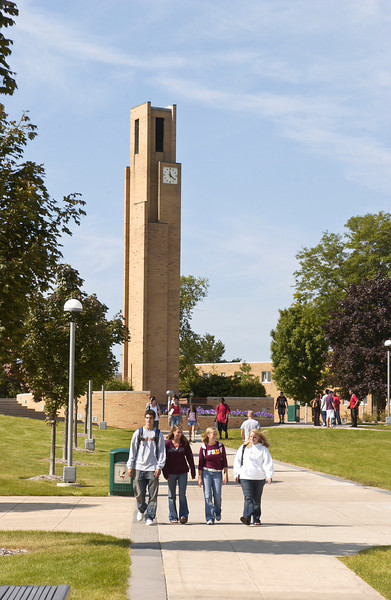

## Assessment in 1985

- First National Conference on Assessment in Higher Education
- Recommended that higher student achievement could be produced by:
  1. Establishing high expectations for students
  2. Involving them in active learning environments
  3. Providing prompt and useful feedback

## Computers in 1985

- Apple 128K
- 128KB RAM
- No hard drive
- 1 3.5" 400KB floppy drive
- Must eject operating system to use another disk

[figure not shown]

## Portable Phones in 1985

- Nokia TalkMan
- First “mobile” phone
- 11 pounds
- Carried in a large bag

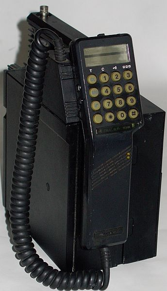

## Engagement

- To increase user engagement:
- Stimulate the seeking system
- Make room for creativity
- Create a safe sandbox
- Capture the process, not just the product

[figure not shown]

## The Assessment Cycle

- Expensive planning and preparation
- Laborious pursuit of the prize
- Brief denouement
- Archive for posterity

[figure not shown]

## A Better Model

> “Assessment is not a spreadsheet – it is a conversation”  
> Irmeli Halinen

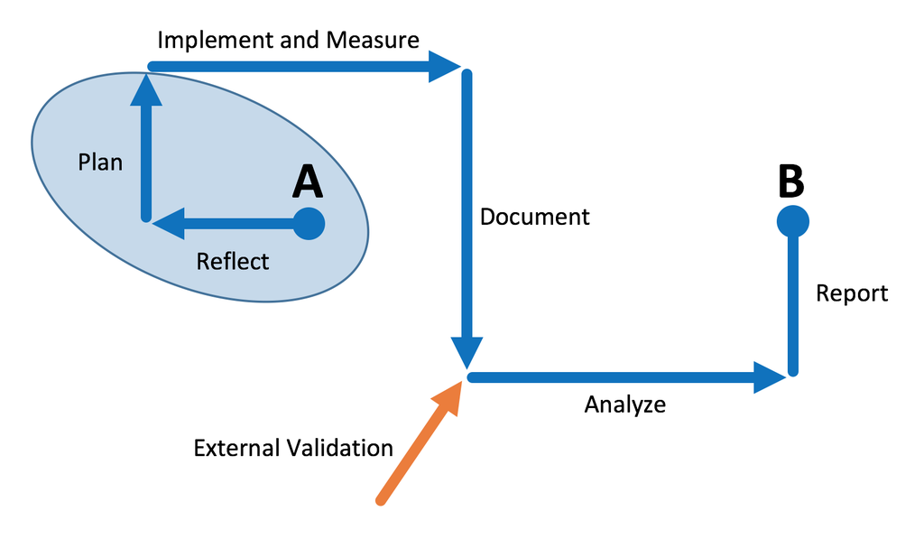

## Reproducible assessment

> Our goal is to create reproducible processes to increase transparency and *encourage faculty engagement*.
- **ALL** assessment resources are public-facing
  - Data reports (PDF and HTML)
  - Data analysis code (R)
  - Deidentified data files (csv)
- All released with MIT or CC-BY licenses
- All results are computationally reproducible and extensible

## An Example of Indirect Assessment

- Graduate Survey Results
- Sent to all graduating seniors
- Both quantitative and qualitative data
- http://www.reproducibleassessment.com/1703/

## Authoring Tools [FREE]

- [R](https://www.r-project.org)
- [RStudio](https://www.rstudio.com) - an IDE
- [Bookdown](https://cran.r-project.org/web/packages/bookdown/bookdown.pdf) - A RStudio package
- [git](https://git-scm.com) - version control
- [LaTeX](http://xetex.sourceforge.net) (XeTeX) - for PDFs

## Publishing Tools [FREE]

- [GitHub](https://github.com) - online version control
- [Open Science Framework](https://osf.io) - free data sharing
- [Disqus](https://disqus.com)
- The sky is the limit on the cloud

## Training Resources [FREE]

- [RStudio Tutorials](https://www.rstudio.com/online-learning/)
- [Bookdown Book](https://bookdown.org/yihui/bookdown/)
- [R for Data Science Book](http://r4ds.had.co.nz)
- [Git Book](https://git-scm.com/book/en/v2)
- [Reproducible Research with R and RStudio Book](https://englianhu.files.wordpress.com/2016/01/reproducible-research-with-r-and-studio-2nd-edition.pdf)
- [R Markdown: The Definitive Guide Book](https://bookdown.org/yihui/rmarkdown/)

## Eight Core Competencies

- Collaboration, Communication, Culture, Diversity, Natural Sciences, Problem Solving, Quantitative Literacy, Self and Society
- Each overseen by a faculty subcommittee (6-10 members)
1. Operational definitions
2. Goals ([Hallmarks of a Bulldog](https://ferris.edu/HTMLS/academics/general-education/competencies/hallmarks.htm))
3. Relevance statements

## Standard Outcomes

- Each competency has four learning outcomes
- Based upon what we want our graduating seniors to look like
- Derived from LEAP
- One outcome measured each semester
- [Rolling two-year program cycle](https://ferris.edu/HTMLS/academics/general-education/evidence/schedule.htm)

## Standard Rubrics

- Derived from VALUE rubrics
- [General Education now has a uniform](http://www.reproducibleassessment.com/1701/):
1. Scoring system (zero to four point scale)
2. Analysis interpretation (four threshold values)
3. Criterion leveling (expectations by course level)

## Standard Measures

- Created in order to get more uniform data collection
- [14 different types](https://ferris.edu/HTMLS/academics/general-education/evidence/measures.htm) of measures are defined
- Instructors can choose to use any one they wish
1. Exams
2. Products
3. Performances

## A General Education Report

- Quantitative Literacy (Math)
- Fall, 2017
- QNT3: Apply approaches – Students apply quantitative approaches within contexts to solve problems and draw plausible conclusions.
- http://www.reproducibleassessment.com/1710/

## Faculty Reception

- Still early in implementation
- Campus politics are difficult at the moment
- Policies are still evolving
- Still, promising early signs

## Future Prospects

- We will be working to enlarge our sampling
- More data could lead to greater granularity
- Longitudinal studies will eventually be possible
- Data may be the basis for future research projects
- Other institutions are encouraged to check out our data and analyses
- A web-based dashboard will be deployed as our dataset becomes more complex

## Summary

- We are creating a *collaborative* assessment environment
- This is more about **process** than **personality**
- Focus is on making a **resource** rather than just **reports**

## Questions?

- All of these resources are linked to from your handouts
- Licensed using either CC-BY 4.0 or MIT
- Feel free to contact me if you have questions or comments

[figure not shown]